# TarefaDois

Mauricio Zalamena Bavaresco

2022-09-29

### 1.Carregue a base de dados e mostre a estrutura do dataset (str()). O arquivo do dataset não pode ser modificado de forma alguma. A leitura deverá tratar qualquer característica do arquivo.

```r
setwd("C:\\Users\\Mauricio\\Desktop\\Material\\Atividades\\Computação aplicada")

dados = read.csv("Dry_Bean_Dataset.csv",sep=";",dec=",")
```

```r
str(dados)
```

```
## 'data.frame':    13611 obs. of  17 variables:
##  $ Area           : int  28395 28734 29380 30008 30140 30279 30477 30519 30685 30834 ...
##  $ Perimeter      : num  610 638 624 646 620 ...
##  $ MajorAxisLength: num  208 201 213 211 202 ...
##  $ MinorAxisLength: num  174 183 176 183 190 ...
##  $ AspectRation   : num  1.2 1.1 1.21 1.15 1.06 ...
##  $ Eccentricity   : num  0.55 0.412 0.563 0.499 0.334 ...
##  $ ConvexArea     : int  28715 29172 29690 30724 30417 30600 30970 30847 31044 31120 ...
##  $ EquivDiameter  : num  190 191 193 195 196 ...
##  $ Extent         : num  0.764 0.784 0.778 0.783 0.773 ...
##  $ Solidity       : num  0.989 0.985 0.99 0.977 0.991 ...
##  $ roundness      : num  0.958 0.887 0.948 0.904 0.985 ...
##  $ Compactness    : num  0.913 0.954 0.909 0.928 0.971 ...
##  $ ShapeFactor1   : num  0.00733 0.00698 0.00724 0.00702 0.0067 ...
##  $ ShapeFactor2   : num  0.00315 0.00356 0.00305 0.00321 0.00366 ...
##  $ ShapeFactor3   : num  0.834 0.91 0.826 0.862 0.942 ...
##  $ ShapeFactor4   : num  0.999 0.998 0.999 0.994 0.999 ...
##  $ Class          : chr  "SEKER" "SEKER" "SEKER" "SEKER" ...
```

### 2.Altere a variável do tipo do feijão (Class) para um factor.

```r
dados$Class = factor(c(dados$Class))
summary(dados$Class)
```

```
## BARBUNYA   BOMBAY     CALI DERMASON    HOROZ    SEKER     SIRA
##     1322      522     1630     3546     1928     2027     2636
```

### 3.Plote um gráfico de barras que ilustre as quantidades de cada classe.

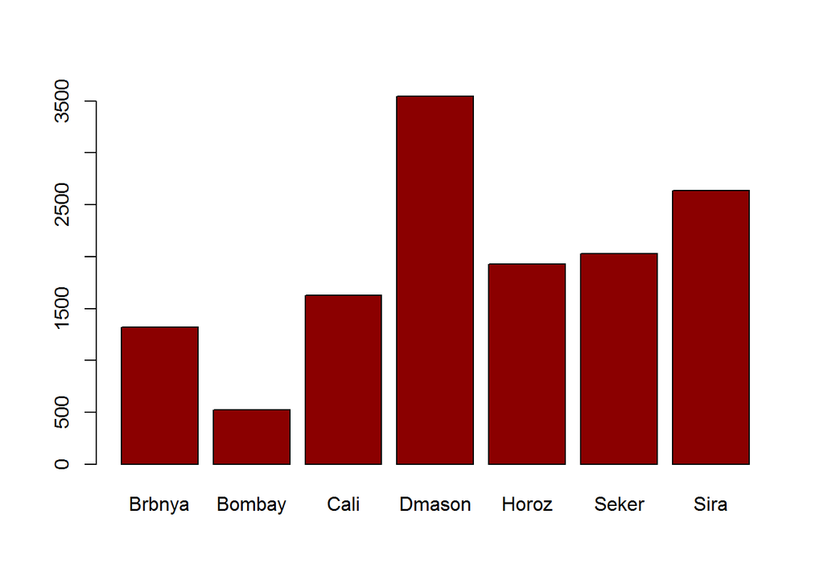

```r
barplot(summary(dados$Class),names.arg = c("Brbnya", "Bombay", "Cali", "Dmason", "Horoz", "Seker", "Sira"),col="darkred")
```

### 4. Realize a normalização dos dados via Z-score. Plote um boxplot para ilustrar a distribuição de cada variável. Mostre as estatísticas de cada variável (summary).

```r
escorez=as.data.frame(lapply(dados[,2:16],function(y)(y-mean(y))/sd(y) ))
```

###ou

```r
escorez=as.data.frame(scale(dados[,2:16]))
```

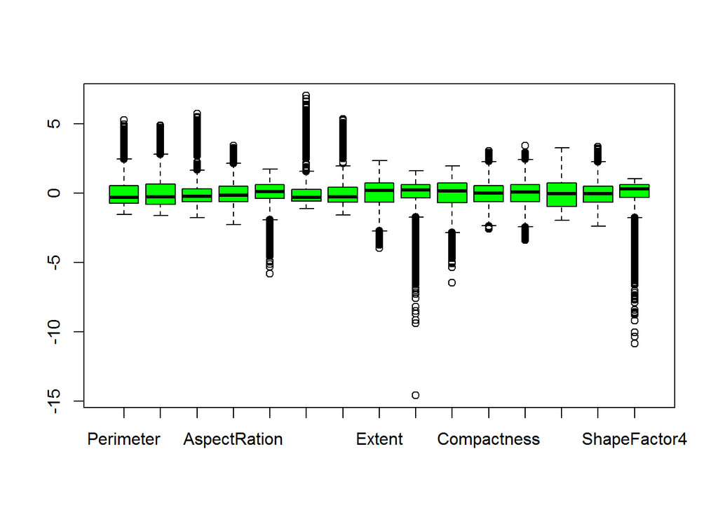

```r
boxplot(escorez,col = "green")
```

```r
summary(escorez)
```

```
##    Perimeter       MajorAxisLength   MinorAxisLength    AspectRation
##  Min.   :-1.5425   Min.   :-1.5933   Min.   :-1.7736   Min.   :-2.2636
##  1st Qu.:-0.7082   1st Qu.:-0.7800   1st Qu.:-0.5876   1st Qu.:-0.6119
##  Median :-0.2816   Median :-0.2714   Median :-0.2188   Median :-0.1302
##  Mean   : 0.0000   Mean   : 0.0000   Mean   : 0.0000   Mean   : 0.0000
##  3rd Qu.: 0.5690   3rd Qu.: 0.6576   3rd Qu.: 0.3282   3rd Qu.: 0.5021
##  Max.   : 5.2736   Max.   : 4.8862   Max.   : 5.7355   Max.   : 3.4339
##   Eccentricity       ConvexArea      EquivDiameter         Extent
##  Min.   :-5.7819   Min.   :-1.1111   Min.   :-1.5516   Min.   :-3.9607
##  1st Qu.:-0.3801   1st Qu.:-0.5728   1st Qu.:-0.6421   1st Qu.:-0.6336
##  Median : 0.1472   Median :-0.2885   Median :-0.2472   Median : 0.2063
##  Mean   : 0.0000   Mean   : 0.0000   Mean   : 0.0000   Mean   : 0.0000
##  3rd Qu.: 0.6475   3rd Qu.: 0.2863   3rd Qu.: 0.4458   3rd Qu.: 0.7562
##  Max.   : 1.7448   Max.   : 7.0359   Max.   : 5.3451   Max.   : 2.3726
##     Solidity          roundness        Compactness       ShapeFactor1
##  Min.   :-14.5689   Min.   :-6.4460   Min.   :-2.5811   Min.   :-3.35603
##  1st Qu.: -0.3160   1st Qu.:-0.6920   1st Qu.:-0.6059   1st Qu.:-0.58838
##  Median :  0.2446   Median : 0.1659   Median : 0.0229   Median : 0.07231
##  Mean   :  0.0000   Mean   : 0.0000   Mean   : 0.0000   Mean   : 0.00000
##  3rd Qu.:  0.6159   3rd Qu.: 0.7323   3rd Qu.: 0.5575   3rd Qu.: 0.62749
##  Max.   :  1.6167   Max.   : 1.9725   Max.   : 3.0373   Max.   : 3.44642
##   ShapeFactor2       ShapeFactor3       ShapeFactor4
##  Min.   :-1.93292   Min.   :-2.35617   Min.   :-10.8500
##  1st Qu.:-0.94387   1st Qu.:-0.62863   1st Qu.: -0.3116
##  Median :-0.03762   Median :-0.01562   Median :  0.3029
##  Mean   : 0.00000   Mean   : 0.00000   Mean   :  0.0000
##  3rd Qu.: 0.76244   3rd Qu.: 0.52948   3rd Qu.:  0.6457
##  Max.   : 3.27086   Max.   : 3.34535   Max.   :  1.0693
```

### 5.Realize a seleção de características (correlação). Plote o gráfico de correlação. Liste as características que foram removidas.

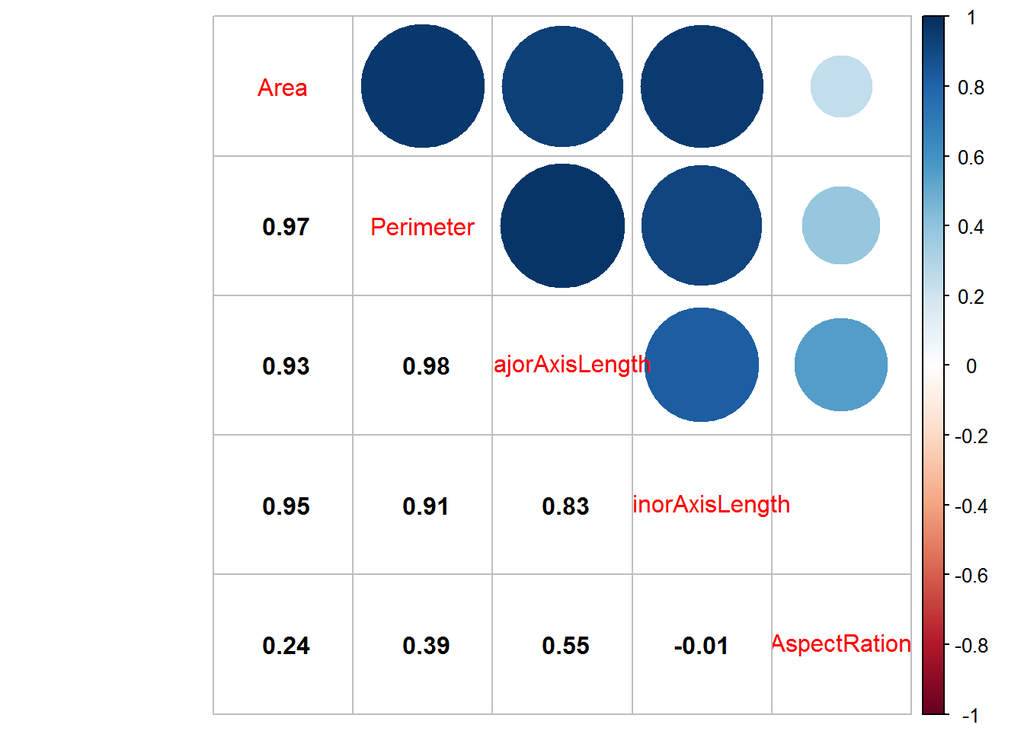

```r
library(corrplot)
library(caret)
dadosCorrelacao = cor(dados[,1:5])
corrplot.mixed(dadosCorrelacao,lower.col = "black")
```

```r
correlacaoAlta = findCorrelation(dadosCorrelacao, cutoff=0.95)
print(correlacaoAlta)
```

```
## [1] 3 2 1
```

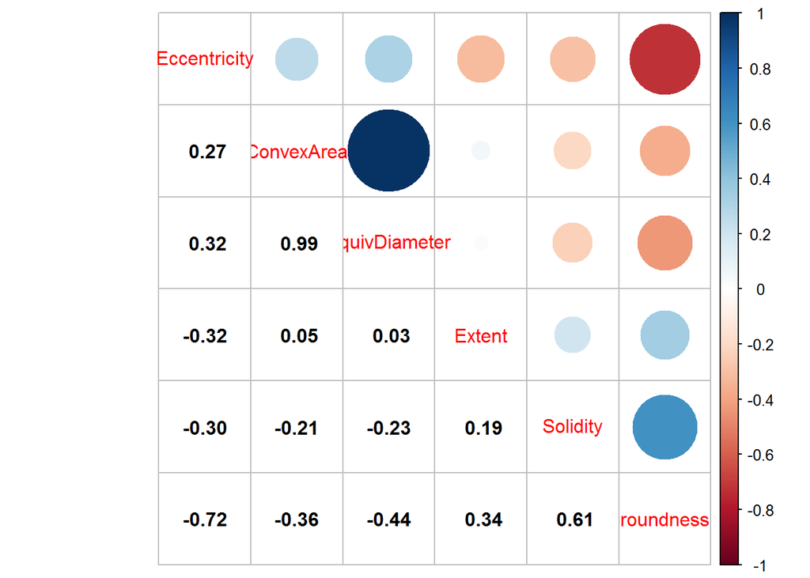

```r
dadosCorrelacao = cor(dados[,6:11])
corrplot.mixed(dadosCorrelacao,lower.col = "black")
```

```r
correlacaoAlta = findCorrelation(dadosCorrelacao, cutoff=0.95)
print(correlacaoAlta)
```

```
## [1] 3
```

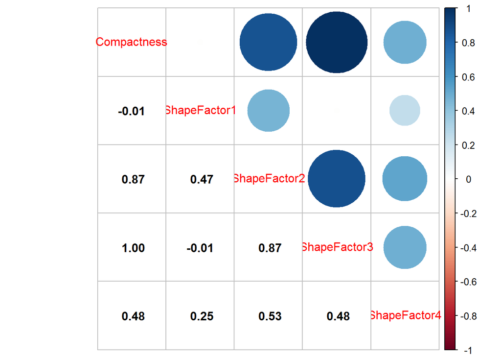

```r
dadosCorrelacao = cor(dados[,12:16])
corrplot.mixed(dadosCorrelacao,lower.col = "black")
```

```r
correlacaoAlta = findCorrelation(dadosCorrelacao, cutoff=0.95)
print(correlacaoAlta)
```

```
## [1] 4
```

### 6.Plote um gráfico boxplot ou de densidade por variável x classe (organize em 3 colunas). Discuta qual é a variável que teria maior poder de discriminação? Existe alguma classe que pode ser classificada mais facilmente? Justifique a sua escolha.

```r
cores = c("red","green","blue","yellow","darkred","black","brown")
par(mfrow=c(1,3))
for (i in 1:16) {
boxplot(dados[,i] ~ dados$Class, col=cores, xlab="Tipo de feijão",
ylab="", main=names(dados)[i])
}
```

[output not shown]

### Na variável Área,Perimeter,MajorAxisLength,MinorAxisLength,ConvexArea,EquivDiameter,ShapeFactor1,ShapeFactor2 pode-se visualizar um maior poder de discriminação na classe BOMBAY porque a mediana da classe está fora das outras caixas e não sobrepõe as outras caixas.

### Na variável AspectRation possuí duas classes com grande poder de discriminação que é a SEKER e HOROZ porque a mediana da classe está fora das outras caixas e não sobrepõe as outras caixas.

### Na variável Eccentricity a classe que possuí maior poder de discriminação é SEKER porque a mediana da classe está fora das outras caixas e não sobrepõe as outras caixas.

### Na variável Extent a classe horoz possuí maior poder de discriminação porque a mediana da classe horoz esta fora da caixa das outras

### Na variável Solidity a classe SEKER possuí maior poder de discriminação porque a mediana está fora das outras caixas

### Na variável roundness a classe SEKER possuí maior poder de discriminação porque a mediana da classe está fora das outras caixas e não sobrepõe as outras caixas.

### Na variável Compactness as classes Seker e Horoz possuem maior poder de discriminação porque a mediana da classe está fora das outras caixas e não sobrepõe as outras caixas.

### Na variavél ShapeFactor3 as classes Seker e Horoz possuem maior poder de discriminação porque a mediana da classe está fora das outras caixas e não sobrepõe as outras caixas.

### Na variável ShapeFactor4 a classe Seker possui o maior poder de discriminação porque a mediana da classe está fora das outras caixas e não sobrepõe as outras caixas.

```r
print(levels(dados$Class))
```

```
## [1] "BARBUNYA" "BOMBAY"   "CALI"     "DERMASON" "HOROZ"    "SEKER"    "SIRA"
```

### 7.Realize a projeção do dataset utilizando PCA. Explique as características dos componentes principais estimados. O que se pode explicar sobre os componentes principais utilizando o gráfico biplot. Apresente as características básicas (summary) dos dados.

```r
pca = prcomp(dados[,2:5], center=TRUE, scale=TRUE)
print(pca)
```

```
## Standard deviations (1, .., p=4):
## [1] 1.72209904 1.01243835 0.07861298 0.05624484
##
## Rotation (n x k) = (4 x 4):
##                       PC1         PC2        PC3         PC4
## Perimeter       0.5770908 -0.08987168  0.8107934  0.03877259
## MajorAxisLength 0.5772849  0.09472639 -0.3657732 -0.72386392
## MinorAxisLength 0.5094353 -0.47175145 -0.4420447  0.56791081
## AspectRation    0.2723673  0.87200949 -0.1158468  0.38986539
```

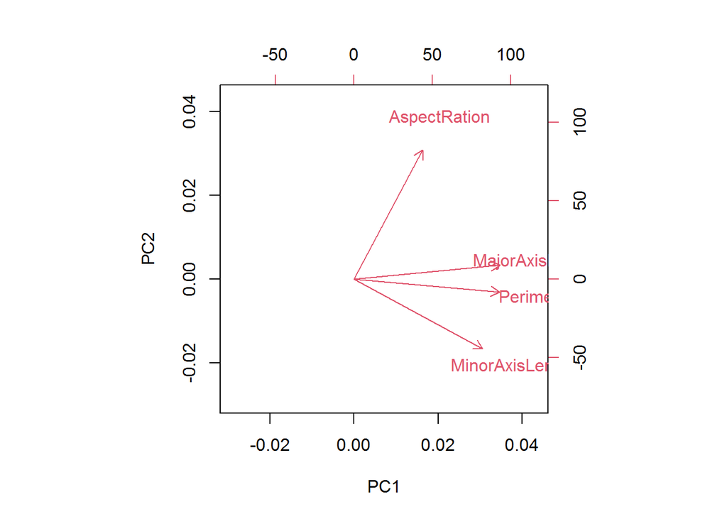

```r
biplot(pca,xlabs = rep("", nrow(dados[,1:16])))
```

```r
summary(pca)
```

```
## Importance of components:
##                           PC1    PC2     PC3     PC4
## Standard deviation     1.7221 1.0124 0.07861 0.05624
## Proportion of Variance 0.7414 0.2563 0.00155 0.00079
## Cumulative Proportion  0.7414 0.9977 0.99921 1.00000
```

### O Gráfico Biplot é um tipo de gráfico exploratório usado em estatística. As variáveis que estão exibidas no gráfico são as variáveis que são linearmente correlacionadas. E os componentes visualizados pelo summary explicam a variância dos dados em relação ao a cada autovetor.